# Feature Selection

# Setup

## Basic setup for plotting and data handling

```r
library(lmPerm) # Library for permutation tests
library(tidyverse) # Tools for data science (graphing, data reorganizing, etc.)
# Some custom graphing stuff
source("./theme_pub.R")
theme_set(theme_pub())
```

## Load filtered & scaled data

```r
InDat<-read.csv("./data/ScaledData.csv")

scalDat<-mutate_if(InDat,is.character,as.factor) # Convert other character cols to factor
scalDat$Batch.Number<-as.factor(scalDat$Batch.Number) # Treat batch as a factor
```

## Filtering

P-values for filtering (after adjusting P for false discovery rate)

```r
PBatch<-0.2 # Batch (and other) effects, keep only metabolites if P > PBatch
PModA<-PModB<-PModC<-PModD<-0.01 # Keep only predictive metabolites with P < this value
PModCT<-0.1 # Keep metabolites correlated with CT value (COVID patients only) based on this P-value
```

# Batch Effects

There are a few options for dealing with batch effects. We’ll start by excluding metabolites that show Class x Batch interactions. These metabolites will complicate our ML models because patients with different diseases show different profiles for these metabolites when run in different batches. This suggests some technical issue that is going to complicate diagnosis and therefore these should be excluded.

## ANOVA test

There are two options here: Basic ANOVA and a permutation ANOVA. The latter estimates p-values by reshuffling the data and comparing observed values to a null distribution. The advantage of permutation is that it makes no assumptions about the data distribution. The downside is that the `lmp()` function to run permutation in R doesn’t seem to return p-values as an object, so I can’t automate feature selection.

> TO DO: Re-run with permutation (`PermMod`) and compare significant interaction terms with those identified by basic ANOVA. Are they consistent?

### Raw Data

```r
PermTest<-FALSE # set to true and re-run chunck to run the same analysis with permutation test for comparison
DescNames<-c("Sample.Name","Batch.Number","Class.name","Sex","Age","CT")
Concs<-names(scalDat)[!names(scalDat) %in% DescNames] # Columns with concentration (metabolite) data
Batch.Interactions<-data.frame(Metabolite=Concs,P=NA)
BasicMod<-function(x,ColDat){
  return(lm(ColDat ~ Batch.Number * Class.name, data=x))
}
PermMod<-function(x,ColDat){
  return(lmp(ColDat ~ Batch.Number * Class.name, data=x,perm="Prob"))
}
Row<-0
for(Col in Concs){
  Row<-Row+1
  cat("----------------------------------------\n")
  cat(paste("ANOVA test of",Col,"\n"))
  print(anova(BasicMod(x=scalDat,ColDat=scalDat[,Col])))
  Batch.Interactions[Row,]<-c(Col,anova(BasicMod(x=scalDat,ColDat=scalDat[,Col]))[[5]][3]) # Save P-values
  if(PermTest==TRUE){
    cat(paste("Permutation test of",Col,"\n"))
    anova(PermMod(x=scalDat,ColDat=scalDat[,Col]))
  }

  cat("----------------------------------------\n\n\n")
}
```

```
## ----------------------------------------
## ANOVA test of Gly
## Analysis of Variance Table
##
## Response: ColDat
##                          Df  Sum Sq Mean Sq F value  Pr(>F)
## Batch.Number              2   2.833  1.4164  3.2582 0.04045 *
## Class.name                4 125.150 31.2876 71.9745 < 2e-16 ***
## Batch.Number:Class.name   8   2.468  0.3085  0.7097 0.68286
## Residuals               206  89.549  0.4347
## ---
## Signif. codes:  0 '***' 0.001 '**' 0.01 '*' 0.05 '.' 0.1 ' ' 1
## ----------------------------------------
##
##
## ----------------------------------------
## ANOVA test of Ala
## Analysis of Variance Table
##
## Response: ColDat
##                          Df  Sum Sq Mean Sq F value    Pr(>F)
## Batch.Number              2   3.666   1.833  5.1090  0.006831 **
## Class.name                4 139.990  34.998 97.5589 < 2.2e-16 ***
## Batch.Number:Class.name   8   2.446   0.306  0.8522  0.557931
## Residuals               206  73.899   0.359
## ---
## Signif. codes:  0 '***' 0.001 '**' 0.01 '*' 0.05 '.' 0.1 ' ' 1
## ----------------------------------------
##
##
## ----------------------------------------
## ANOVA test of Ser
## Analysis of Variance Table
##
## Response: ColDat
##                          Df  Sum Sq Mean Sq  F value  Pr(>F)
## Batch.Number              2   2.684   1.342   3.9914 0.01992 *
## Class.name                4 145.462  36.366 108.1683 < 2e-16 ***
## Batch.Number:Class.name   8   2.598   0.325   0.9660 0.46368
## Residuals               206  69.256   0.336
```

[output cut: 1799 more lines]

```
##
##
## ----------------------------------------
## ANOVA test of C18.1OH
## Analysis of Variance Table
##
## Response: ColDat
##                          Df  Sum Sq Mean Sq F value    Pr(>F)
## Batch.Number              2  27.526 13.7628  23.981 4.336e-10 ***
## Class.name                4  23.028  5.7569  10.031 1.948e-07 ***
## Batch.Number:Class.name   8  51.223  6.4029  11.157 4.509e-13 ***
## Residuals               206 118.224  0.5739
## ---
## Signif. codes:  0 '***' 0.001 '**' 0.01 '*' 0.05 '.' 0.1 ' ' 1
## ----------------------------------------
```

```r
Batch.Interactions$P<-as.numeric(Batch.Interactions$P)
```

### Filter features

Remove features with significant interaction effects.

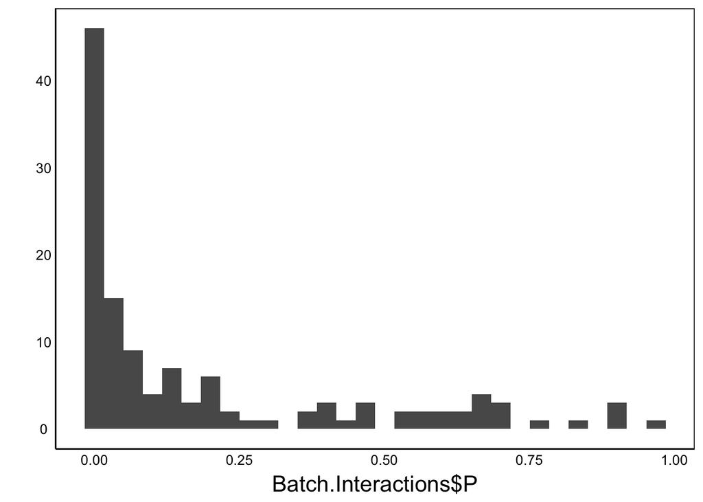

```r
qplot(Batch.Interactions$P) # Full data
```

# False Discovery Rate

## Benjamini-Hochberg FDR

Instructions to adjust for false discovery based on the the B-H method. Can be calculated manually using the p-values above:

1. Make a new data table and input p-values from each metabolite in a column.
2. Sort from lowest to highest.
3. Add a 2nd column assigning ranks (1 lowest to N highest).
4. Add a 3rd column to Calculate the B-H value, using the formula:

$$C = \frac{R}{N}\alpha$$
where: $R$ is is the rank of the p-value $N$ is the number of tests (i.e. metabolites): 124 $\alpha$ is the desired FDR (e.g. 0.05)

4. Find the largest $p < C$.
5. All p-values up to this rank are significant at adjusted $p = \alpha$

## FDR Calculation

> Decide how stringent to be. E.g. keep anything that is non-significant after adjusting for false-discovery rate vs. higher p-value like 0.1 or 0.2.

```r
BIsort<-Batch.Interactions[order(Batch.Interactions$P),]
BIsort$Rank<-c(1:nrow(BIsort))
BIsort$BH<-BIsort$Rank/nrow(BIsort)*PBatch
```

### Filtered Metabolites

```r
ConcKeep<-BIsort$Metabolite[BIsort$P>BIsort$BH]
ConcRem<-BIsort$Metabolite[BIsort$P<=BIsort$BH]

cat("----------------------------------------\n")
paste("Metabolites removed: ",paste(ConcRem, collapse=", "))
```

```
## [1] "Metabolites removed:  Glu, Sarcosine, C18.1OH, C16.2, C14, C14.2OH, C18.2, C6, C16.2OH, C4, C12, C4OH, C5.1DC, C3OH, C5DC, C10.2, C0, C6.1, C16OH, C8, PC36.0AE, Leu, C18, PC40.6AE, C12DC, PC32.2AA, C10.1, PC36.6AA, PC40.1AA, PC40.2AA, X18.1SM, PC38.0AA, C10, PC36.0AA, LYSOC20.3, X20.2SM, C5.…
```

```r
cat("----------------------------------------\n")
paste("Metabolites kept: ",paste(ConcKeep, collapse=", "))
```

```
## [1] "Metabolites kept:  X14.1SMOH, C16, C3, Spermine, C3.1, Lactic.acid, Glucose, X16.0SM, C18.1, Taurine, X16.1SM, LYSOC18.2, Isobutyric.acid, Met, Fumaric.acid, Kynurenine, C16.1, C5MDC, Pyruvic.acid, C5, Histamine, total.DMA, Citric.acid, LYSOC14.0, Ser, Thr, Ac.Orn, Asp, Putrescine, Succinic.…
```

```r
cat("----------------------------------------\n")
```

# Batch effects

Remove batch effects for remaining metabolites by taking the residuals of a linear model with Batch as the predictor variable.

```r
Concs<-ConcKeep  # Define concentration columns to keep based on filters above
resDat<-scalDat[,Concs]*0 # Subset data and set to 0
```

Write a function to calculate residuals given input data x and predictor column Resp

```r
BasicLM<-function(x,Resp){ # x is the full data frame, Resp is just the predictor column (vector)
  return(lm(Resp ~ x$Batch.Number)$residuals)
}
```

Apply the function to the input data and save the output

```r
for(Col in 1:ncol(resDat)){
  ColName<-names(resDat)[Col]
  resDat[,Col]<-BasicLM(x=scalDat,Resp=scalDat[,ColName])
}
```

Add the grouping columns back

```r
resDat<-cbind(scalDat[,c("Sample.Name","Batch.Number","Class.name","Sex","Age","CT")],resDat)
```

# Feature Selection

## 1. Subset A: Respiratory vs Control

Filter features that differ among one or more groups.

```r
PATdat<-resDat %>% # Dataset with new encoding
  filter(Class.name %in% c("COVID19","Influenza","RSV","Control"))
PATdat$Class.name<-recode_factor(PATdat$Class.name, COVID19 = "Resp", Influenza = "Resp", RSV = "Resp")

FtestOutA<-data.frame(Metabolite=Concs,P=NA)
GrpMod<-function(x,ColDat){
  return(lm(ColDat ~ Class.name, data=x))
}
Row<-0
for(Col in Concs){
  Row<-Row+1
  cat("----------------------------------------\n")
  cat(paste("ANOVA test of",Col,"\n"))
  print(anova(GrpMod(x=PATdat,ColDat=PATdat[,Col])))
  FtestOutA[Row,]<-c(Col,anova(GrpMod(x=PATdat,ColDat=PATdat[,Col]))[[5]][1]) # Save p-value
  cat("----------------------------------------\n\n\n")
}
```

```
## ----------------------------------------
## ANOVA test of X14.1SMOH
## Analysis of Variance Table
##
## Response: ColDat
##             Df  Sum Sq Mean Sq F value    Pr(>F)
## Class.name   1  26.182 26.1815  30.651 9.252e-08 ***
## Residuals  208 177.670  0.8542
## ---
## Signif. codes:  0 '***' 0.001 '**' 0.01 '*' 0.05 '.' 0.1 ' ' 1
## ----------------------------------------
##
##
## ----------------------------------------
## ANOVA test of C16
## Analysis of Variance Table
##
## Response: ColDat
##             Df  Sum Sq Mean Sq F value  Pr(>F)
## Class.name   1   2.258 2.25802  3.0711 0.08117 .
## Residuals  208 152.930 0.73524
## ---
## Signif. codes:  0 '***' 0.001 '**' 0.01 '*' 0.05 '.' 0.1 ' ' 1
## ----------------------------------------
##
##
## ----------------------------------------
## ANOVA test of C3
## Analysis of Variance Table
##
## Response: ColDat
##             Df  Sum Sq Mean Sq F value   Pr(>F)
## Class.name   1   5.572  5.5722  6.9537 0.008996 **
## Residuals  208 166.676  0.8013
## ---
## Signif. codes:  0 '***' 0.001 '**' 0.01 '*' 0.05 '.' 0.1 ' ' 1
## ----------------------------------------
##
##
## ----------------------------------------
```

[output cut: 539 more lines]

```
## Residuals  208 199.078  0.9571
## ---
## Signif. codes:  0 '***' 0.001 '**' 0.01 '*' 0.05 '.' 0.1 ' ' 1
## ----------------------------------------
##
##
## ----------------------------------------
## ANOVA test of Butyric.acid
## Analysis of Variance Table
##
## Response: ColDat
##             Df  Sum Sq Mean Sq F value Pr(>F)
## Class.name   1   0.755 0.75479  0.7324 0.3931
## Residuals  208 214.368 1.03062
## ----------------------------------------
```

```r
FtestOutA$P<-as.numeric(FtestOutA$P)
```

### FDR Calculation

```r
GrpSortA<-FtestOutA[order(FtestOutA$P),]
GrpSortA$Rank<-c(1:nrow(GrpSortA))
GrpSortA$BH<-GrpSortA$Rank/nrow(GrpSortA)*PModA
```

#### Filtered Metabolites

NOTE the direction >< vs filtering for Batch effects (now we want to keep significant effects)

```r
ConcKeepA<-GrpSortA$Metabolite[GrpSortA$P<GrpSortA$BH]
ConcRemA<-GrpSortA$Metabolite[GrpSortA$P>=GrpSortA$BH]

cat("----------------------------------------\n")
paste("Metabolites removed: ",paste(ConcRemA, collapse=", "))
```

```
## [1] "Metabolites removed:  C3, total.DMA, C3.1, Ac.Orn, Spermine, C16, Succinic.acid, Carnosine, Propionic.acid, Cit, Fumaric.acid, Pyruvic.acid, C16.1, Taurine, Butyric.acid, C18.1, Nitro.Tyr, LYSOC14.0, Isobutyric.acid, C5MDC"
```

```r
cat("----------------------------------------\n")
paste("Metabolites kept: ",paste(ConcKeepA, collapse=", "))
```

```
## [1] "Metabolites kept:  Phe, Ile, Asp, Tyr, Val, Met.SO, Arg, His, Pro, Ala, Thr, Kynurenine, Gly, Lys, Ser, LYSOC18.2, X16.1SM, Met, Lactic.acid, X16.0SM, Putrescine, X14.1SMOH, Citric.acid, Orn, C5, beta.Hydroxybutyric.acid, Histamine, Glucose"
```

```r
cat("----------------------------------------\n")
```

## 2. Subset B: COVID vs Other Resp

Features that distinguish COVID from other respiratory Disease

```r
COVIDdat<-resDat %>% # Dataset with new encoding
  filter(Class.name %in% c("COVID19","Influenza","RSV"))
COVIDdat$Class.name<-recode_factor(COVIDdat$Class.name, Influenza = "Other", RSV = "Other")

FtestOutB<-data.frame(Metabolite=Concs,P=NA) # Reset output dataframe
Row<-0
for(Col in Concs){
  Row<-Row+1
  cat("----------------------------------------\n")
  cat(paste("ANOVA test of",Col,"\n"))
  print(anova(GrpMod(x=COVIDdat,ColDat=COVIDdat[,Col])))
  FtestOutB[Row,]<-c(Col,anova(GrpMod(x=COVIDdat,ColDat=COVIDdat[,Col]))[[5]][1]) # Save P-value
  cat("----------------------------------------\n\n\n")
}
```

```
## ----------------------------------------
## ANOVA test of X14.1SMOH
## Analysis of Variance Table
##
## Response: ColDat
##             Df Sum Sq Mean Sq F value Pr(>F)
## Class.name   1  0.880 0.88003   1.486 0.2246
## Residuals  164 97.126 0.59223
## ----------------------------------------
##
##
## ----------------------------------------
## ANOVA test of C16
## Analysis of Variance Table
##
## Response: ColDat
##             Df  Sum Sq Mean Sq F value Pr(>F)
## Class.name   1   0.153 0.15316  0.1693 0.6812
## Residuals  164 148.323 0.90441
## ----------------------------------------
##
##
## ----------------------------------------
## ANOVA test of C3
## Analysis of Variance Table
##
## Response: ColDat
##             Df  Sum Sq Mean Sq F value Pr(>F)
## Class.name   1   0.295 0.29512  0.3221 0.5711
## Residuals  164 150.244 0.91612
## ----------------------------------------
##
##
## ----------------------------------------
## ANOVA test of Spermine
## Analysis of Variance Table
##
## Response: ColDat
##             Df  Sum Sq Mean Sq F value Pr(>F)
## Class.name   1   1.027 1.02708   1.189 0.2771
```

[output cut: 507 more lines]

```
## Signif. codes:  0 '***' 0.001 '**' 0.01 '*' 0.05 '.' 0.1 ' ' 1
## ----------------------------------------
##
##
## ----------------------------------------
## ANOVA test of Butyric.acid
## Analysis of Variance Table
##
## Response: ColDat
##             Df  Sum Sq Mean Sq F value  Pr(>F)
## Class.name   1   5.571  5.5715  6.2072 0.01372 *
## Residuals  164 147.205  0.8976
## ---
## Signif. codes:  0 '***' 0.001 '**' 0.01 '*' 0.05 '.' 0.1 ' ' 1
## ----------------------------------------
```

```r
FtestOutB$P<-as.numeric(FtestOutB$P)
```

### FDR Calculation

> Another stringency value (lower = stronger predictor)

```r
GrpSortB<-FtestOutB[order(FtestOutB$P),]
GrpSortB$Rank<-c(1:nrow(GrpSortB))
GrpSortB$BH<-GrpSortB$Rank/nrow(GrpSortB)*PModB
```

#### Filtered Metabolites

NOTE the direction >< vs filtering for Batch effects (now we want to keep significant effects)

```r
ConcKeepB<-GrpSortB$Metabolite[GrpSortB$P<GrpSortB$BH]
ConcRemB<-GrpSortB$Metabolite[GrpSortB$P>=GrpSortB$BH]

cat("----------------------------------------\n")
paste("Metabolites removed: ",paste(ConcRemB, collapse=", "))
```

```
## [1] "Metabolites removed:  Glucose, Taurine, Ile, C3.1, Butyric.acid, Val, Putrescine, Lactic.acid, Met, Arg, Ala, Phe, Nitro.Tyr, C5, C16.1, Propionic.acid, C5MDC, Fumaric.acid, X14.1SMOH, His, Lys, Spermine, C18.1, Asp, Thr, Orn, Citric.acid, X16.1SM, Kynurenine, Ser, Cit, C3, X16.0SM, Pro, LYS…
```

```r
cat("----------------------------------------\n")
paste("Metabolites kept: ",paste(ConcKeepB, collapse=", "))
```

```
## [1] "Metabolites kept:  Carnosine, Met.SO, beta.Hydroxybutyric.acid, LYSOC18.2, Succinic.acid"
```

```r
cat("----------------------------------------\n")
```

Features that distinguish each category

```r
ALLdat<-resDat %>% # Dataset with new encoding
  filter(Class.name %in% c("COVID19","Influenza","RSV","Control"))

FtestOutC<-data.frame(Metabolite=Concs,P=NA) # Reset output dataframe
Row<-0
for(Col in Concs){
  Row<-Row+1
  cat("----------------------------------------\n")
  cat(paste("ANOVA test of",Col,"\n"))
  print(anova(GrpMod(x=ALLdat,ColDat=ALLdat[,Col])))
  FtestOutC[Row,]<-c(Col,anova(GrpMod(x=ALLdat,ColDat=ALLdat[,Col]))[[5]][1]) # Save P-value
  cat("----------------------------------------\n\n\n")
}
```

```
## ----------------------------------------
## ANOVA test of X14.1SMOH
## Analysis of Variance Table
##
## Response: ColDat
##             Df Sum Sq Mean Sq F value    Pr(>F)
## Class.name   3  27.28  9.0932  10.609 1.623e-06 ***
## Residuals  206 176.57  0.8571
## ---
## Signif. codes:  0 '***' 0.001 '**' 0.01 '*' 0.05 '.' 0.1 ' ' 1
## ----------------------------------------
##
##
## ----------------------------------------
## ANOVA test of C16
## Analysis of Variance Table
##
## Response: ColDat
##             Df  Sum Sq Mean Sq F value Pr(>F)
## Class.name   3   2.501 0.83374  1.1249   0.34
## Residuals  206 152.687 0.74120
## ----------------------------------------
##
##
## ----------------------------------------
## ANOVA test of C3
## Analysis of Variance Table
##
## Response: ColDat
##             Df  Sum Sq Mean Sq F value   Pr(>F)
## Class.name   3  12.535  4.1785  5.3895 0.001368 **
## Residuals  206 159.713  0.7753
## ---
## Signif. codes:  0 '***' 0.001 '**' 0.01 '*' 0.05 '.' 0.1 ' ' 1
## ----------------------------------------
##
##
## ----------------------------------------
## ANOVA test of Spermine
## Analysis of Variance Table
```

[output cut: 547 more lines]

```
## Residuals  206 178.282  0.8654
## ---
## Signif. codes:  0 '***' 0.001 '**' 0.01 '*' 0.05 '.' 0.1 ' ' 1
## ----------------------------------------
##
##
## ----------------------------------------
## ANOVA test of Butyric.acid
## Analysis of Variance Table
##
## Response: ColDat
##             Df Sum Sq Mean Sq F value Pr(>F)
## Class.name   3   6.33  2.1101  2.0819 0.1037
## Residuals  206 208.79  1.0136
## ----------------------------------------
```

```r
FtestOutC$P<-as.numeric(FtestOutC$P)
```

### FDR Calculation

> Another stringency value (lower = stronger predictor)

```r
GrpSortC<-FtestOutC[order(FtestOutC$P),]
GrpSortC$Rank<-c(1:nrow(GrpSortC))
GrpSortC$BH<-GrpSortC$Rank/nrow(GrpSortC)*PModC
```

#### Filtered Metabolites

NOTE the direction >< vs filtering for Batch effects (now we want to keep significant effects)

```r
ConcKeepC<-GrpSortC$Metabolite[GrpSortC$P<GrpSortC$BH]
ConcRemC<-GrpSortC$Metabolite[GrpSortC$P>=GrpSortC$BH]

cat("----------------------------------------\n")
paste("Metabolites removed: ",paste(ConcRemC, collapse=", "))
```

```
## [1] "Metabolites removed:  C5MDC, C3.1, Taurine, LYSOC14.0, total.DMA, Spermine, Ac.Orn, Butyric.acid, Fumaric.acid, Propionic.acid, C16.1, Nitro.Tyr, Pyruvic.acid, C16, Cit, C18.1, Isobutyric.acid"
```

```r
cat("----------------------------------------\n")
paste("Metabolites kept: ",paste(ConcKeepC, collapse=", "))
```

```
## [1] "Metabolites kept:  Phe, Ile, Met.SO, Asp, Val, Tyr, Arg, His, Ala, Pro, LYSOC18.2, Thr, Kynurenine, Gly, Lys, Ser, Carnosine, Met, X16.1SM, Lactic.acid, beta.Hydroxybutyric.acid, Putrescine, X16.0SM, Citric.acid, X14.1SMOH, Glucose, Orn, C5, Succinic.acid, C3, Histamine"
```

```r
cat("----------------------------------------\n")
```

## 4. Correlations with COVID CT

```r
ALLdat<-scalDat %>% # Dataset with new encoding
  filter(Class.name %in% c("COVID19"))
CTMod<-function(x,ColDat){
  return(lm(ColDat ~ as.numeric(CT) + Batch.Number, data=x))
}

CTtestOut<-data.frame(Metabolite=Concs,P=NA) # Reset output dataframe
Row<-0
for(Col in Concs){
  Row<-Row+1
  cat("----------------------------------------\n")
  cat(paste("ANOVA test of",Col,"\n"))
  print(anova(CTMod(x=ALLdat,ColDat=ALLdat[,Col])))
  CTtestOut[Row,]<-c(Col,anova(CTMod(x=ALLdat,ColDat=ALLdat[,Col]))[[5]][1]) # Save P-value
  cat("----------------------------------------\n\n\n")
}
```

```
## ----------------------------------------
## ANOVA test of X14.1SMOH
## Analysis of Variance Table
##
## Response: ColDat
##                Df Sum Sq Mean Sq F value Pr(>F)
## as.numeric(CT)  1  1.646  1.6461  1.5288 0.2221
## Batch.Number    2  2.315  1.1575  1.0750 0.3491
## Residuals      50 53.838  1.0768
## ----------------------------------------
##
##
## ----------------------------------------
## ANOVA test of C16
## Analysis of Variance Table
##
## Response: ColDat
##                Df Sum Sq Mean Sq F value Pr(>F)
## as.numeric(CT)  1  3.328  3.3278  1.6945 0.1990
## Batch.Number    2  5.450  2.7249  1.3875 0.2591
## Residuals      50 98.195  1.9639
## ----------------------------------------
##
##
## ----------------------------------------
## ANOVA test of C3
## Analysis of Variance Table
##
## Response: ColDat
##                Df  Sum Sq Mean Sq F value    Pr(>F)
## as.numeric(CT)  1  2.3582  2.3582   4.452   0.03989 *
## Batch.Number    2 14.0369  7.0184  13.250 2.414e-05 ***
## Residuals      50 26.4850  0.5297
## ---
## Signif. codes:  0 '***' 0.001 '**' 0.01 '*' 0.05 '.' 0.1 ' ' 1
## ----------------------------------------
##
##
## ----------------------------------------
## ANOVA test of Spermine
```

[output cut: 561 more lines]

```
## Batch.Number    2  0.210 0.10519  0.1169 0.8899
## Residuals      50 44.998 0.89996
## ----------------------------------------
##
##
## ----------------------------------------
## ANOVA test of Butyric.acid
## Analysis of Variance Table
##
## Response: ColDat
##                Df Sum Sq Mean Sq F value Pr(>F)
## as.numeric(CT)  1  1.207 1.20703  0.6138 0.4371
## Batch.Number    2  0.680 0.34004  0.1729 0.8417
## Residuals      50 98.329 1.96658
## ----------------------------------------
```

```r
CTtestOut$P<-as.numeric(CTtestOut$P)
```

### FDR Calculation

> Another stringency value (lower = stronger predictor)

```r
GrpSortCT<-CTtestOut[order(CTtestOut$P),]
GrpSortCT$Rank<-c(1:nrow(GrpSortCT))
GrpSortCT$BH<-GrpSortCT$Rank/nrow(GrpSortCT)*PModCT
```

#### Filtered Metabolites

NOTE the direction >< vs filtering for Batch effects (now we want to keep significant effects)

```r
ConcKeepCT<-GrpSortCT$Metabolite[GrpSortCT$P<GrpSortCT$BH]
ConcRemCT<-GrpSortCT$Metabolite[GrpSortCT$P>=GrpSortCT$BH]

cat("----------------------------------------\n")
paste("Metabolites removed: ",paste(ConcRemCT, collapse=", "))
```

```
## [1] "Metabolites removed:  Fumaric.acid, Arg, Taurine, Asp, C3, Gly, Thr, His, Histamine, C3.1, Lys, Pro, Ser, C16, Met, Ile, Val, X14.1SMOH, Glucose, Phe, Succinic.acid, Tyr, X16.0SM, LYSOC14.0, C18.1, Ala, Orn, Pyruvic.acid, X16.1SM, C16.1, Butyric.acid, Putrescine, Carnosine, Nitro.Tyr, Isobut…
```

```r
cat("----------------------------------------\n")
paste("Metabolites kept: ",paste(ConcKeepCT, collapse=", "))
```

```
## [1] "Metabolites kept:  C5, Kynurenine, total.DMA, Spermine"
```

```r
cat("----------------------------------------\n")
```

# Output

Save data for downstream analysis.

Filtered + Residuals from Batch Effects:

```r
write.csv(resDat,"./data/ResidualData.csv",row.names=F)
```

Filtered + Residuals + Significant Metabolites from Batch Effects:

Group A (see above)

```r
write.csv(resDat[,c("Sample.Name","Batch.Number","Class.name","Sex","Age","CT",
                    ConcKeepA)],"./data/FeatDatA.csv",row.names=F)
```

Group B (see above)

```r
write.csv(resDat[,c("Sample.Name","Batch.Number","Class.name","Sex","Age","CT",
                    ConcKeepB)],"./data/FeatDatB.csv",row.names=F)
```

Group C (see above)

```r
write.csv(resDat[,c("Sample.Name","Batch.Number","Class.name","Sex","Age","CT",
                    ConcKeepC)],"./data/FeatDatC.csv",row.names=F)
```

Group CT (see above)

```r
write.csv(resDat[,c("Sample.Name","Batch.Number","Class.name","Sex","Age","CT",
                    ConcKeepCT)],"./data/FeatDatCT.csv",row.names=F)
```

# Test Residuals

```r
PermTest<-FALSE # Set to TRUE to output permutation models
DescNames<-c("Sample.Name","Batch.Number","Class.name","Sex","Age","CT")
Concs<-names(scalDat)[!names(scalDat) %in% DescNames] # Columns with concentration (metabolite) data
PermMod<-function(x,ColDat){
  return(lmp(ColDat ~ Batch.Number + Class.name, data=x,perm="Prob"))
}

if(PermTest==TRUE){
  for(Col in Concs){
    cat("----------------------------------------\n")
    cat(paste("Permutation test of",Col,"\n"))
    anova(PermMod(x=resDat,ColDat=resDat[,Col]))
    cat("----------------------------------------\n\n\n")
  }
}
```